# R Notebook

# 9 visualizing data distributions

In this Chapter, we first discuss properties of a variety of distributions and how to visualize distributions using a motivating example of student heights. We then discuss the ggplot2 geometries for these visualizations in Section 9.16. # 9.1 variable types We will be working with two types of variables: categorical and numeric. Each can be divided into two other groups: categorical can be ordinal or not, whereas numerical variables can be discrete or continuous.

# 9.2 Case study: describing student heights

```r
library(tidyverse)
library(dslabs)
data(heights)
head(heights)
```

# 9.3 Distribution function

```r
heights%>%frequency(sex)
```

```
[1] 1
```

# 9.4 Cumulative distribution functions

F(a)=Pr(x≤a)

we can see that 16% of the values are below 65, since F(66)=0.164, or that 84% of the values are below 72, since F(72)=0.841, etc.

# 9.5 histograms

CDF= not very popular in practice it does not easily convey characteristics of interest such as: at what value is the distribution centered? Is the distribution symmetric? What ranges contain 95% of the values?

What information do we lose? Note that all values in each interval are treated the same when computing bin heights. So, for example, the histogram does not distinguish between 64, 64.1, and 64.2 inches.

# 9.6 smoothed density

We therefore make a histogram, using bin sizes appropriate for our data and computing frequencies rather than counts, and we draw a smooth curve that goes through the tops of the histogram bars.

We should select a degree of smoothness that we can defend as being representative of the underlying data

# 9.6.1 interpreting the y-axis

Note that interpreting the y-axis of a smooth density plot is not straightforward. It is scaled so that the area under the density curve adds up to 1. If you imagine we form a bin with a base 1 unit in length, the y-axis value tells us the proportion of values in that bin. However, this is only true for bins of size 1. For other size intervals, the best way to determine the proportion of data in that interval is by computing the proportion of the total area contained in that interval.

# 9.6.2 densities permit stratification

we point out that an advantage of smooth densities over histograms for visualization purposes is that densities makes it easier to compare two distributions.

# 9.7 exercises

24% of the states

A. The graph above is a histogram.

B. The graph above shows only four numbers with a bar plot.

C. Categories are not numbers, so it does not make sense to graph the distribution.

D. The colors, not the height of the bars, describe the distribution.

B

A. 100%

B. 95%

C. 80%

D. 72 inches

B

4.To the closest inch, what height m has the property that 1/2 of the male students are taller than m and 1/2 are shorter?

A. 61 inches

B. 64 inches

C. 69 inches

D. 74 inches

C

A. 1

B. 5

C. 10

D. 50

A

B. Most states have murder rates below 2 per 100,000.

C. All the states have murder rates above 2 per 100,000.

D. With the exception of 4 states, the murder rates are below 5 per 100,000.

D

A. 10

B. 24

C. 34

D. 100

C

8.About what percentage are shorter than 60 inches?

A. 1%

B. 10%

C. 25%

D. 50%

A

A. 0.02

B. 0.15

C. 0.50

D. 0.55

C

A. It is impossible that they are from the same dataset.

B. They are from the same dataset, but the plots are different due to code errors.

C. They are the same dataset, but the first and second plot undersmooth and the third oversmooths.

D. They are the same dataset, but the first is not in the log scale, the second undersmooths and the third oversmooths.

A

# 9.8 the normal distribution

The distribution is symmetric, centered at the average, and most values (about 95%) are within 2 SDs from the average.

```r
m<-sum(x)/length(x)
```

and the SD is defined as:

```r
s<-sqrt(sum(x-mu)^2)/length(x)
```

```r
index<-heights$sex=='Male'
x<-heights$height[index]
```

```r
m<-mean(x)
s<-sd(x)
c(average=m,sd=s)
```

```
  average        sd
69.314755  3.611024
```

# 9.9 standard units

for a value x from a vector X, we define the value of x in standard units as z = (x - m)/s with m and s the average and standard deviation of X respectively

```r
z<-scale(x)
z
```

```r
mean(abs(z)<2)
```

```
[1] 0.9495074
```

# 9.10 Quantile-quantile plots

Φ(x)to define the function that gives us the probability of a standard normal distribution being smaller than x.So,for example, Φ(−1.96)=0.025 and Φ(1.96)=0.975 . In R, we can evaluate Φ using the pnorm function:

```r
pnorm(1.96)
```

```
[1] 0.9750021
```

The inverse function Φ−1(x)gives us the theoretical quantiles for the normal distribution. So, for example, Φ−1(0.975)=1.96. In R, we can evaluate the inverse of Φ using the qnorm function.

```r
qnorm(0.975)
```

```
[1] 1.959964
```

```r
qnorm(0.975,mean=5,sd=2)
```

```
[1] 8.919928
```

```r
mean(x<=69.5)
```

```
[1] 0.5147783
```

```r
x2<-c(1,2,3,4,5,6,7)
mean(x2<=5)
```

```
[1] 0.7142857
```

```r
p<-seq(0.05,0.95,0.05)
```

```r
sample_quantiles<-quantile(x,p)
```

```r
theoretical_quantiles<-qnorm(p,mean=mean(x),sd=sd(x))
```

[figure not shown]

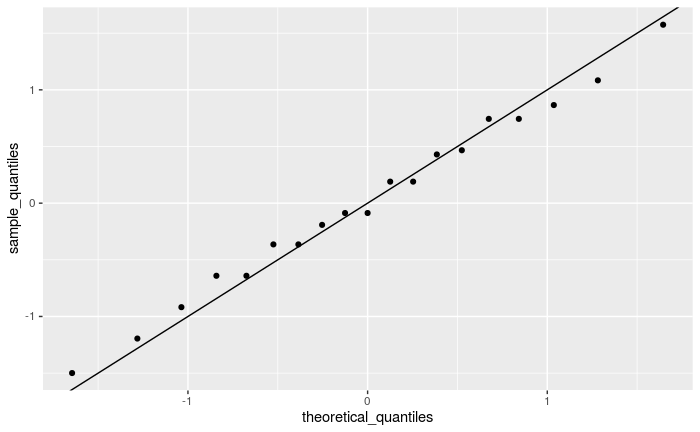

```r
sample_quantiles <- quantile(z, p)
theoretical_quantiles <- qnorm(p)
qplot(theoretical_quantiles, sample_quantiles) + geom_abline()
```

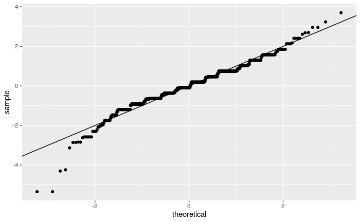

```r
heights %>% filter(sex=="Male") %>%
  ggplot(aes(sample = scale(height))) +
  geom_qq() +
  geom_abline()
```

# 9.11 percentiles

Percentiles are special cases of quantiles that are commonly used. The percentiles are the quantiles you obtain when setting the p at 0.01,0.02,…,0.99. We call, for example, the case of p=0.25 the 25th percentile, which gives us a number for which 25% of the data is below. The most famous percentile is the 50th, also known as the median.

# 9.12 boxplots

we know that the median is about 2.5, that the distribution is not symmetric, and that the range is 0 to 5 for the great majority of states with two exceptions.

# 9.13 stratification

we divide the height values into groups based on a sex variable: females and males. We call this procedure stratification and refer to the resulting groups as strata.

Stratification is common in data visualization because we are often interested in how the distribution of variables differ across different subgroups.

# 9.14 case study:describing student heights

```r
heights%>%filter(sex=='Female')%>%top_n(5,desc(height))%>%pull(height)
```

```
[1] 51 53 55 52 52
```